# Predicting complex phase diagrams

### Steps to calculate the solubility gap of Co$_x$Mn$_{3-x}$O$_4$ alloys.

Contents:

- Machine-learned ab initio data
- The right way to calculate free energies
- Calculation of the solubility gap

## Data

### 1. Reading data

The data have been previously generated by DFT calculations using vasp. There are three different sets of data, corresponding to the way the octahedral and tetrahedral sites are preferentially filled by Co.

```python
# Global variables
formUnits = 8.0 # For free E per formula unit
atomTot = 56.0 # For free E per atom

import numpy as np
import pandas as pd
# Read in set AB data and set C data
AB = np.loadtxt('AB_df_scaled.dat', skiprows=1, unpack=True)
C = np.loadtxt('C_MTP_df_scaled.dat', skiprows=1, unpack=True)
# Concatenate data and create df
AB_df = pd.DataFrame({'Co_count': AB[0], 'oh_count': AB[1], 'E': AB[2], 'form_E': AB[3], 'mag_states': AB[4], 'scaling_factor': AB[7]})
C_df = pd.DataFrame({'Co_count': C[0], 'oh_count': C[1], 'E': C[2], 'form_E': C[3], 'mag_states': C[4], 'scaling_factor': C[6]})
ABC_df = pd.concat([AB_df, C_df], ignore_index=True)
ABC_df_sorted = ABC_df.sort_values(by=['Co_count', 'oh_count'], ignore_index=True)
```

### 2. Calculating the partition function and the Helmholtz free energy

```python
import math
from numpy import log as ln

def make_F_T_array(ABC_df_sorted,T):
    k_B = 1.38064852e-23
    eV_to_joule = 1.60218e-19
    print('calculating T = ',T)
    boltz_T = ABC_df_sorted['form_E'].apply(lambda E : math.exp(-(E*eV_to_joule)/(k_B*T)))
    ABC_df_sorted['boltz_T_scaled'] = boltz_T*ABC_df_sorted['scaling_factor']
    ABC_df_sorted['boltz_T_scaled_mag'] = boltz_T*ABC_df_sorted['scaling_factor']*ABC_df_sorted['mag_states']
    # Groupby Co_count and sum to get partition functions
    Z_T_config_only = ABC_df_sorted.groupby(['Co_count'])['boltz_T_scaled'].sum()
    Z_T_config_mag = ABC_df_sorted.groupby(['Co_count'])['boltz_T_scaled_mag'].sum()
    # Use partition functions calculated above and divide by formUnits to get F(Co_count, T)
    # with and without magnetic entropy.
    F_T_config_only = -k_B*T*ln(ABC_df_sorted.groupby(['Co_count'])['boltz_T_scaled'].sum())/ (formUnits*eV_to_joule)
    F_T_config_mag = -k_B*T*ln(ABC_df_sorted.groupby(['Co_count'])['boltz_T_scaled_mag'].sum())/ (formUnits*eV_to_joule)
    return F_T_config_only, F_T_config_mag
```

```python
the_temperatures = np.arange(50.,2550.,100.)
F_all_T = [make_F_T_array(ABC_df_sorted,T) for T in the_temperatures]
```

```
calculating T =  50.0
calculating T =  150.0
calculating T =  250.0
calculating T =  350.0
calculating T =  450.0
calculating T =  550.0
calculating T =  650.0
calculating T =  750.0
calculating T =  850.0
calculating T =  950.0
calculating T =  1050.0
calculating T =  1150.0
calculating T =  1250.0
calculating T =  1350.0
calculating T =  1450.0
calculating T =  1550.0
calculating T =  1650.0
calculating T =  1750.0
calculating T =  1850.0
calculating T =  1950.0
calculating T =  2050.0
calculating T =  2150.0
calculating T =  2250.0
calculating T =  2350.0
calculating T =  2450.0
```

Since we will need them later, we approximate the T=0 data by the ones at T=50K.

```python
F_all_T_conf_only = [F[0] for F in F_all_T]
F_all_T_conf_mag = [F[1] for F in F_all_T]
```

## Calculating gaps

### 1. Let's define the functions we need

#### a) Function to interpolate $F(T,x)$:

This is important, since we need smooth functions whose derivates we can calculate, in order to determine coexistence curves.

```python
# Function to innterpolate the configurational and magnetic free energies
from scipy import interpolate
def interpolate_F(Fconfonly,Fconfmag,temperatures,**ss):
    Fc = np.array([F.to_numpy() for F in Fconfonly])
    Fm = np.array([Fcmag.to_numpy() - Fcon for Fcon,Fcmag in zip(Fc,Fconfmag)])
    x = np.arange(0,Fc[0].size)
    y = np.array(temperatures)
    [a,b] = np.meshgrid(x,y)
    wght=np.meshgrid([1]+[0 for ii in range(23)]+[1],y)
    fcc = interpolate.bisplrep(a, b, Fc,w=10*np.ravel(wght[0])+1.,**ss)
    fmm = interpolate.bisplrep(a, b, Fm,w=10*np.ravel(wght[0])+1.,**ss)
    return fcc, fmm
```

#### b) Function to plot free energies:

This is just convenient to keep notebook clean from pyplot commands later.

```python
# Function to plot a set of interpolated free energies
'''
Inputs:
    f: and array containing interpolated functions of x and T.
    xrange: a real number corresponding to the maximum Co count.
    T: an array of temperatures at which to plot the functions.
Outputs:
    Plot of all the functions versus concentration x, for all the specified temperatures.
'''
%matplotlib inline
import matplotlib.pyplot as plt

def plot_F(f,xrange,T):
    x = np.arange(0,xrange, 1e-2)
    for myf in f:
        for myT in T:
            z = [myf(xx, myT) for xx in x]
            plt.plot(x, z)
    plt.show()
```

#### c) Function to determine the coexistence regions (i.e. solubility gaps)

```python
from scipy.optimize import fsolve
import math
def CDE_gap_bounded(fcev,fcev_p,temps,numx,*attributes):
    yyfunc = lambda x:0.0+(numx-0.0)/(1.+np.exp(-x))
    mygap =[]
    initsearch = (-1.,2) #these initial values need to be tuned by hand, to guarantee finding the solutions
    for T in temps:
        def ff(p):
            y1,y2 = yyfunc(p[0]),yyfunc(p[1])
            return(lambda x1,x2:
                   ((fcev(T,x1) - fcev(T,x2))/(x1-x2) - fcev_p(T,x1),(fcev(T,x1) - fcev(T,x2))/(x1-x2) - fcev_p(T,x2)))(y1,y2)
        gap = fsolve(ff,initsearch,factor=.1)
        initsearch = gap
        mygap = mygap + [[yyfunc(gap[0]),yyfunc(gap[1])]]
        plt.plot(np.arange(0,numx,.01),[fcev(T,xii) for xii in np.arange(0,numx,.01)])
        plt.plot([yyfunc(gap[0]),yyfunc(gap[1])],[fcev(T,xii) for xii in [yyfunc(gap[0]),yyfunc(gap[1])]])
    plt.show()
    plt.plot(np.array(mygap)[:,0],temps)
    plt.plot(np.array(mygap)[:,1],temps)
    return mygap
```

##### Let's see how this function works

First, interpolate the free energy. `fcev` is the free energy with only configurational entropy contributions, whereas `fev` contains both configurational and magnetic entropy contributions. We also calculate their first derivative with respect to $x$, `fcev_p` and `fev_p`.

```python
fcc,fmm = interpolate_F(F_all_T_conf_only,F_all_T_conf_mag,the_temperatures,s=0.02)
fcev = (lambda t,x: interpolate.bisplev(x,t,fcc))
fcev_p = (lambda t,x: interpolate.bisplev(x,t,fcc,1,0))
fev = (lambda t,x: interpolate.bisplev(x,t,fcc) + interpolate.bisplev(x,t,fmm))
fev_p = (lambda t,x: interpolate.bisplev(x,t,fcc,1,0) + interpolate.bisplev(x,t,fmm,1,0))
```

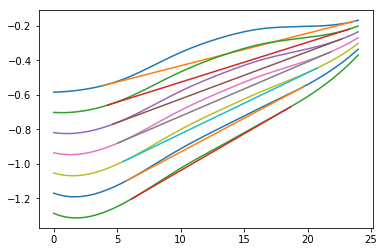

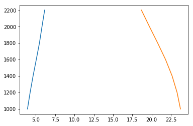

```python
CDE_gap_bounded(fev,fev_p,[1000.+ii*200. for ii in range(7)],24.);
```

The obtained solubility gap is **very different from the one observed experimentally**. The yellow highlighted area is the coexistence region, where the system is a mixture of two phase domains with compositions corresponding to the left and right hand limits of the yellow range at that temperature:

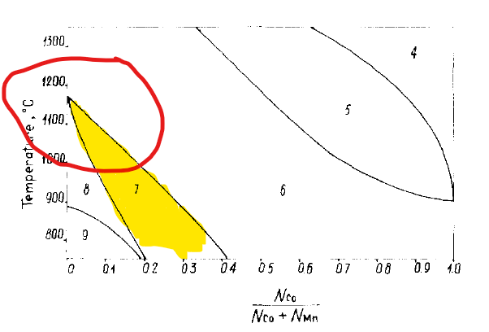

#### d) Function to correct the configurational free energy near the composition edges

This function corrects the entropy, replacing the 24 atom combinations, $\log(N! / n! (24 - n)!$, by the inifite atom combinations, $N \log(N/e) - n \log(n/e) - (24 - n) \log((24 - n)/e)$. Its importance will become clear later.

```python
from scipy.special import gamma as gammaf
def corrector(nn):
    d=0.0001
    N = 24
    n = nn*(1-2.*d/N)+d
    aa = 1000.
    return (N*np.log(aa*N) - n*np.log(aa*n) - (N-n)*np.log(aa*(N-n))) / np.log(gammaf(N+1)/(gammaf(n+1)*gammaf(N-n+1)))
```

The difference with the uncorrected one is not noticeable in this case. But it will become crucial to understand the experimental solubility gap:

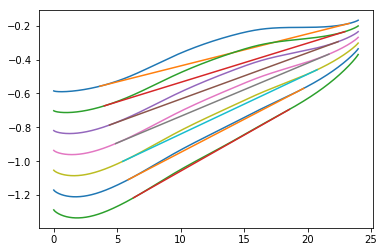

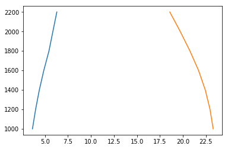

```python
corrected_fev = lambda y,x:(fev(y,x)+(corrector(x)-1)*(fcev(y,x)-fcev(55.,x)))
from scipy.misc import derivative
corrector_p = lambda x: derivative(corrector,x,0.000001)
corrected_fev_p = lambda y,x:(fev_p(y,x)+(corrector(x)-1)*(fcev_p(y,x)-fcev_p(55.,x))+corrector_p(x)*(fcev(y,x)-fcev(55.,x)))
CDE_gap_bounded(corrected_fev,corrected_fev_p,[1000.+ii*200. for ii in range(7)],24.);
```

### 2. Solubility gaps with separate curves for two phases

The experimental solubility gap cannot be explained using only the curves above. This is clear when realizing that there is a tetragonal to cubic phase transition for the pure Mn$_3$O$_4$ phase, at a temperature $T_c\sim 1443\text{K}$. We need to consider a free energy curve $F(T,x)$ consisting of the lowest free energy amongst the two competing phases.

We do not have an *ab initio* $F_\text{cub}$ curve for the cubic phase. But we know a few things about it:

```python
Tc=1443.
Ecub=.2
coef=0.01

Fcub = lambda T,x: corrected_fev(T,x) + Ecub*(1 - (T/Tc)**2)*(24.-x)/24. - coef*x
Fcub_p = lambda T,x: corrected_fev_p(T,x) + Ecub*(1 - (T/Tc)**2)*(-1.)/24. - coef

F2phases = lambda T,x: min([corrected_fev(T,x),Fcub(T,x)])
F2phases_p = lambda T,x: (sorted([[corrected_fev(T,x),corrected_fev_p(T,x)],[Fcub(T,x),Fcub_p(T,x)]],key = lambda funct: funct[0])[0])[1]
```

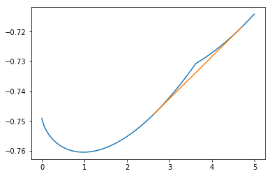

```
[[2.6400413453573295, 4.6986892777377784]]
```

[figure not shown]

```python
CDE_gap_bounded(F2phases,F2phases_p,[1280.],5.)
```

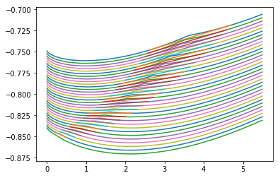

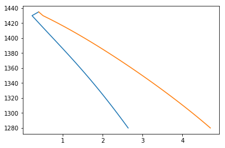

```python
temps=[1280.+ii*5. for ii in range(32)]
mygap=CDE_gap_bounded(F2phases,F2phases_p,temps,5.5)
```

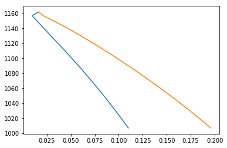

```python
plt.plot(np.array(mygap)[:,0]/24,np.array(temps)-273)
plt.plot(np.array(mygap)[:,1]/24,np.array(temps)-273)
```